# Homework M3

Emily Shepherd

2022-09-03

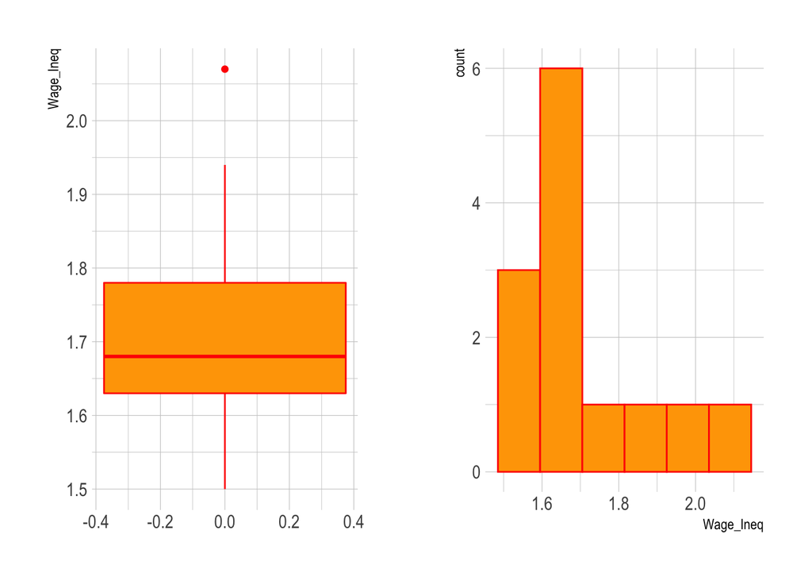

```
##    Min. 1st Qu.  Median    Mean 3rd Qu.    Max.    NA's
##   1.500   1.630   1.680   1.712   1.780   2.070       4
```

The distribution of wage inequality is skewed right. From the boxplot, we can see that there is a single outlier on the high side, which is the wage inequality for the United States. The distribution is centered at the median, 1.68. The middle 50% of the values fall between 1.63 and 1.78.

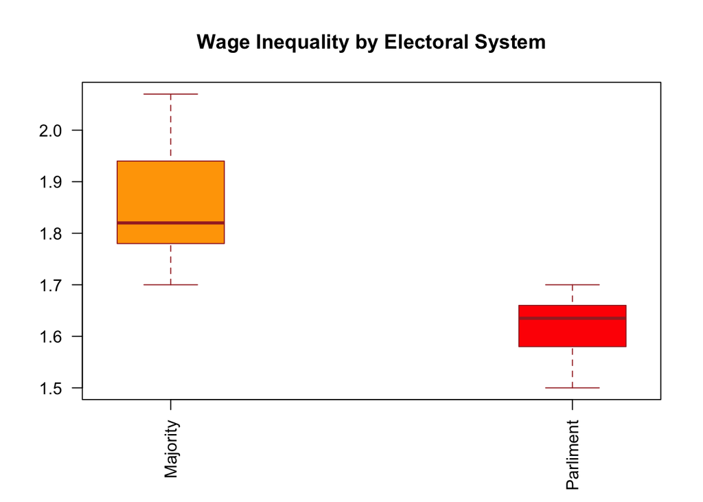

```
##    Min. 1st Qu.  Median    Mean 3rd Qu.    Max.    NA's
##   1.700   1.780   1.820   1.862   1.940   2.070       3
```

```
##    Min. 1st Qu.  Median    Mean 3rd Qu.    Max.    NA's
##   1.500   1.580   1.635   1.619   1.650   1.700       1
```

From the boxplots above, it is evident that the wage inequality is higher under majoritarian systems than parliamentarian systems. The maximum value of wage inequality under the countries with parliamentarian systems is equal to the minimum value for the countries with majoritarian rule.

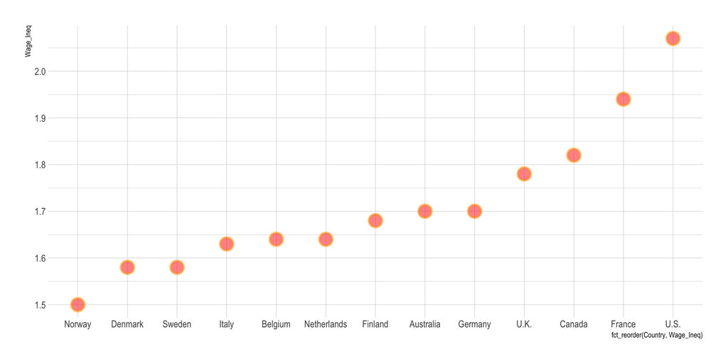

The plot above reinforces what we have observed in the grouped boxplots. The countries with parliamentarian systems of elections have lower wage inequality than countries with a majoritarian system. The Scandanavien countries have the lowest wage inequality. Moving right on the graph towards Canada, France, and the United States, the plot becomes steeper as the wage inequality increases.